[figure not shown]

# Friends Text Analysis

## Overview

### **Most Popular Locations and Phrases in the TV Show**

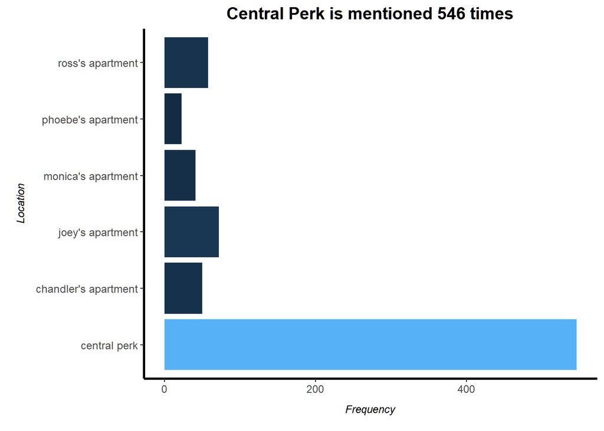

### **Most popular phrases used by the main characters from friends and the number of times it is used by them**

**Catchphrases of Ross**

[figure not shown]

| Catchphrases | Count |
| --- | --- |
| WE WERE ON A BREAK | 18 |
| Paleontology | 46 |
| Divorce | 38 |

**Catchphrases of Joey**

[figure not shown]

| Catchphrases | Count |
| --- | --- |
| JOEY DOES NOT SHARE FOOD | 4 |
| How you doin? | 40 |
| An actor | 115 |
| Dr. Drake Ramore | 62 |

**Catchphrases of Monica**

[figure not shown]

| Catchphrases | Count |
| --- | --- |
| I KNOW! | 171 |
| My Restaurant | 27 |
| SEVEN! | 19 |
| MOM! | 65 |

**Catchphrases of Rachel**

[figure not shown]

| Catchphrases | Count |
| --- | --- |
| Job | 72 |
| NOOOOO! | 26 |
| It is so Pretty | 52 |

**Catchphrases of Phoebe**

[figure not shown]

| Catchphrases | Count |
| --- | --- |
| Smelly Cat | 38 |
| My lobster | 25 |
| Twin sister | 76 |

**Catchphrases of Chandler**

[figure not shown]

| Catchphrases | Count |
| --- | --- |
| Joey | 372 |
| Monica | 252 |
| Oh MY GOD! | 71 |

### **Ross is mentioned most number of times in the script**

However, the name of Phoebe is used as Pheebs and it is mentioned 441 times in the script.

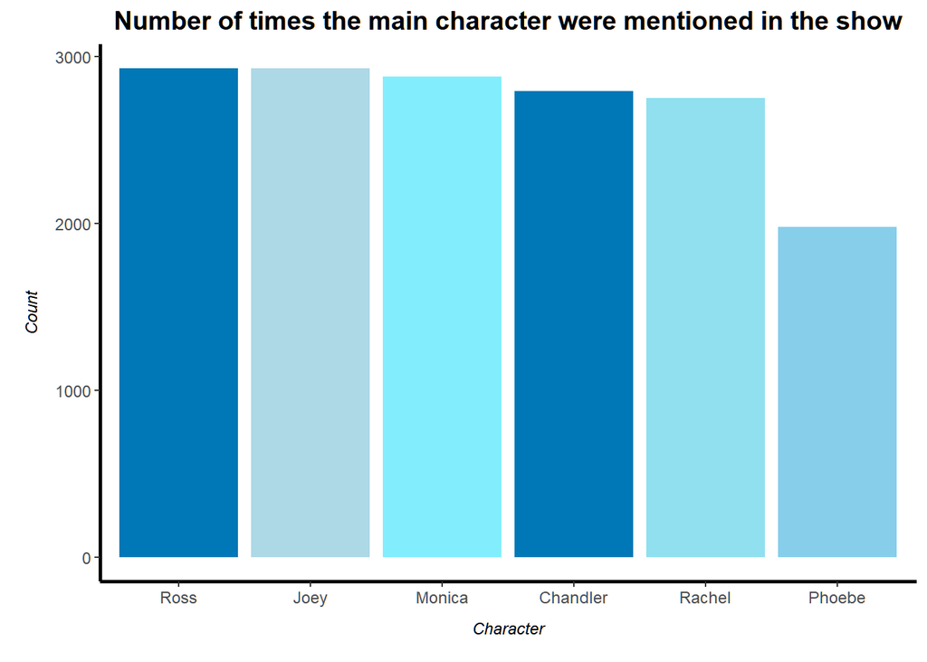

## Episodes and Seasons

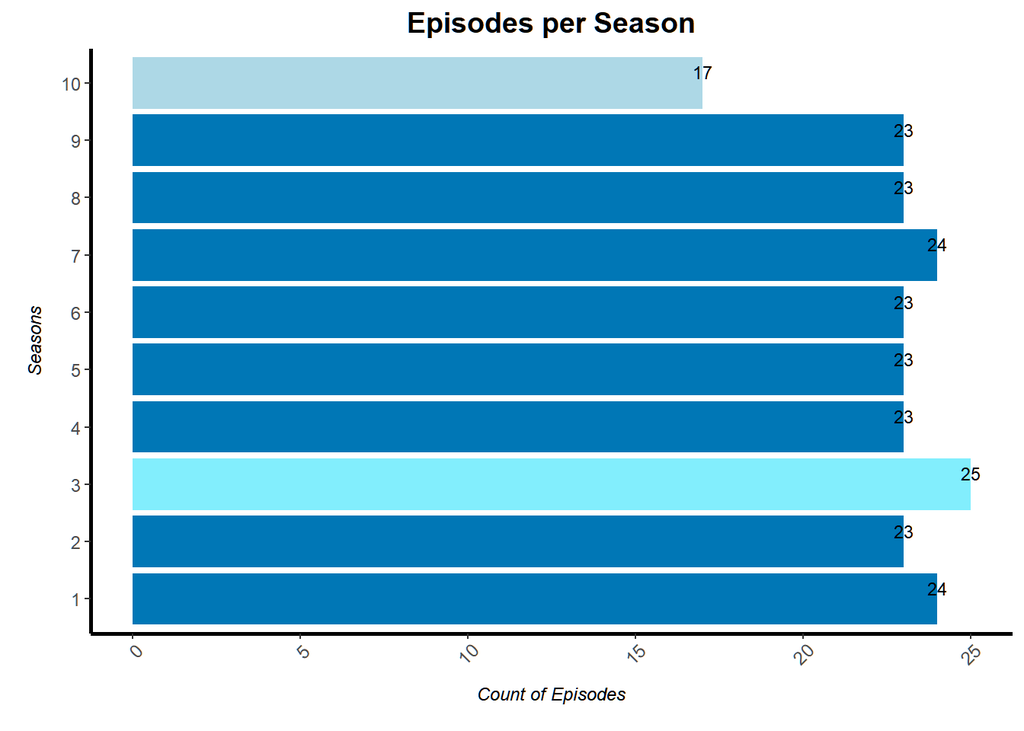

### **Number of Lines in all episodes (1-228) all seasons are clustered in 3 different ways**

Some episodes have more than **500 lines** while most episodes are clustered below **300 lines**

However, Season 09, Episode 23 has the highest number of lines - **623** and Season 10, Episode 17 has **610 lines**

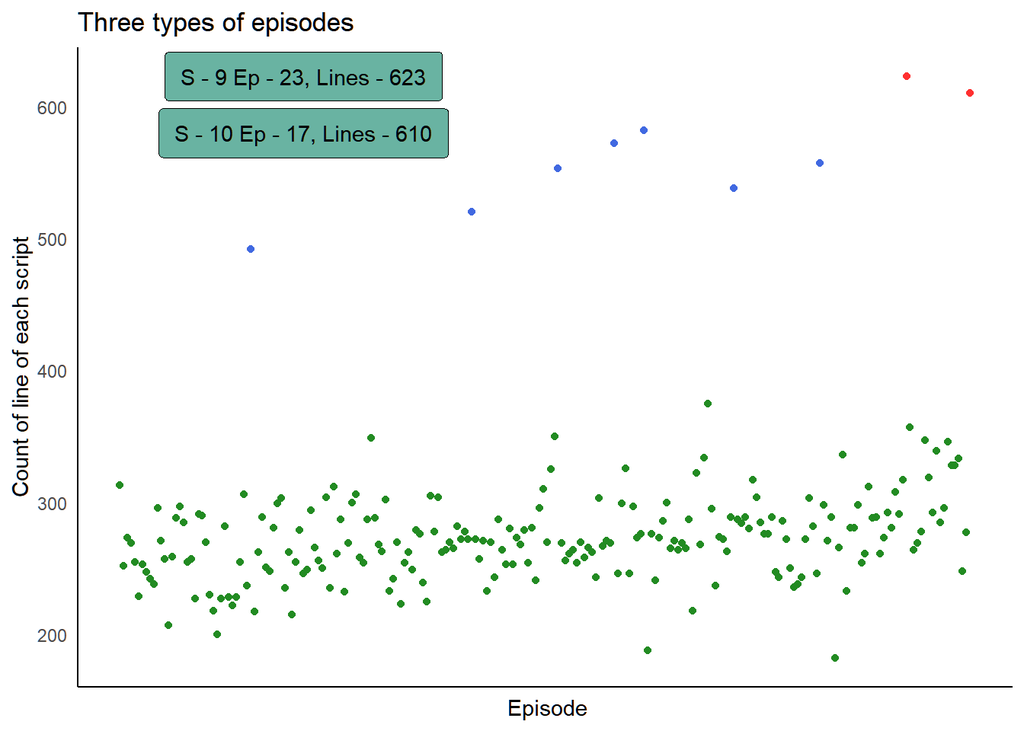

### **Most Used Trigrams Across All Seasons**

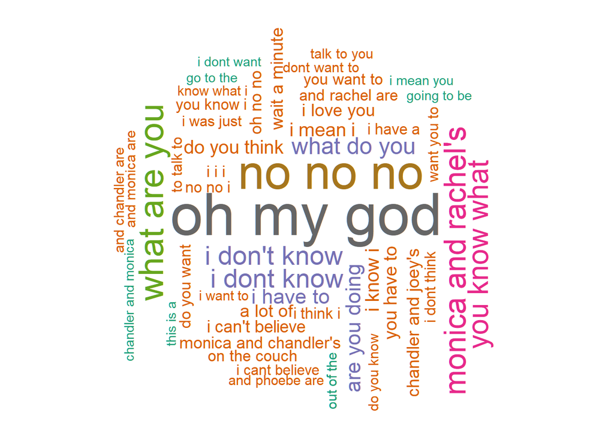

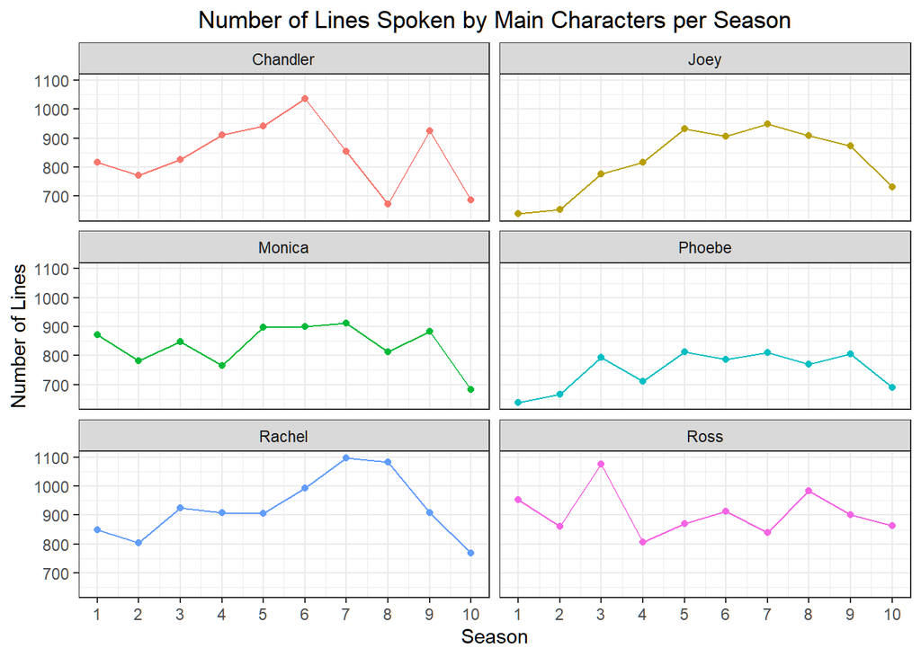

### **Wordcloud of Rachel’s most frequent words**

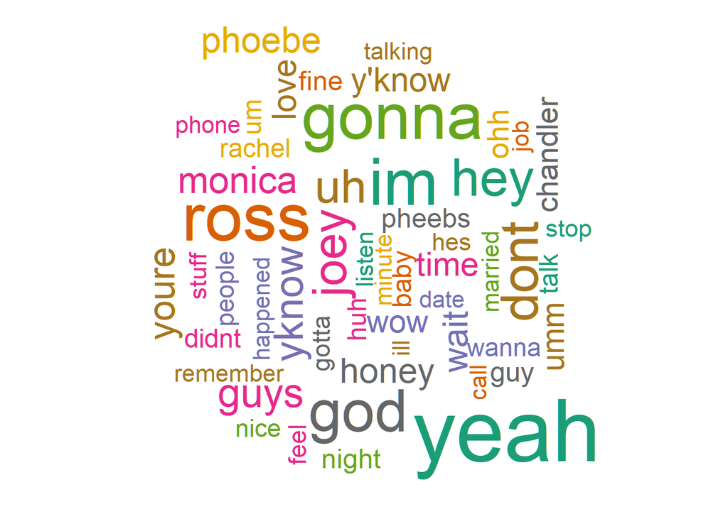

### **Wordcloud of Joey’s most frequent words**

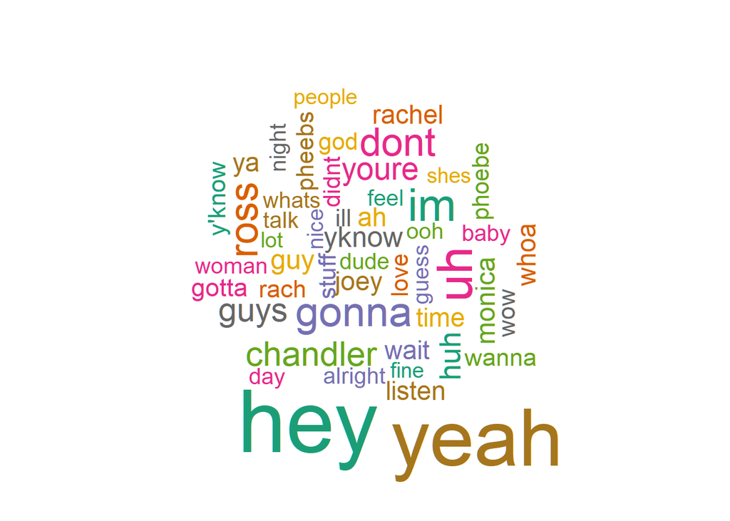

### **Wordcloud of Ross’s most frequent words**

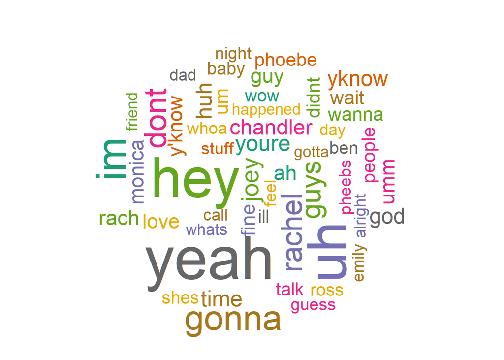

### **Wordcloud of Chandler’s most frequent words**

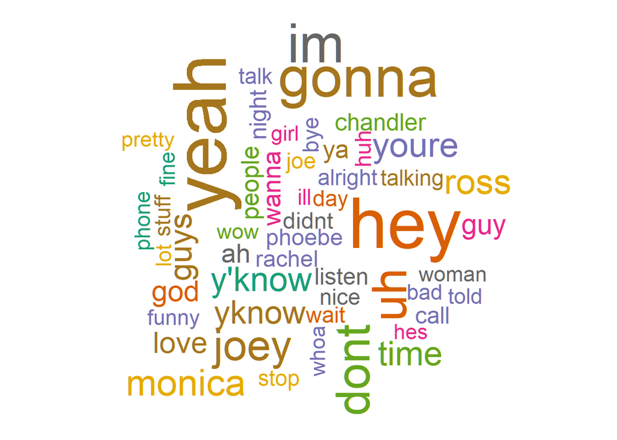

### **Wordcloud of Phoebe’s most frequent words**

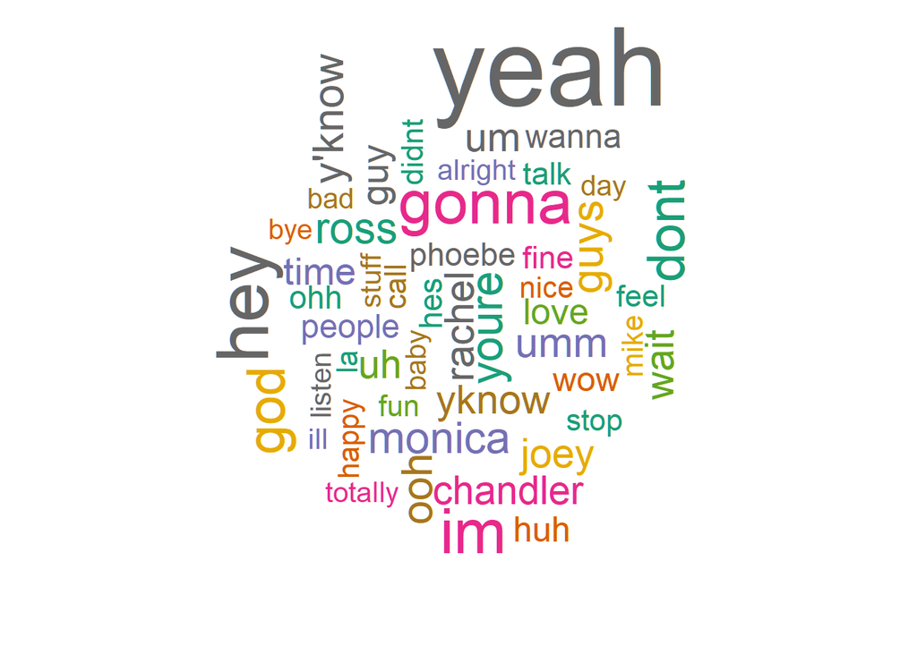

### **Wordcloud of Monica’s most frequent words**

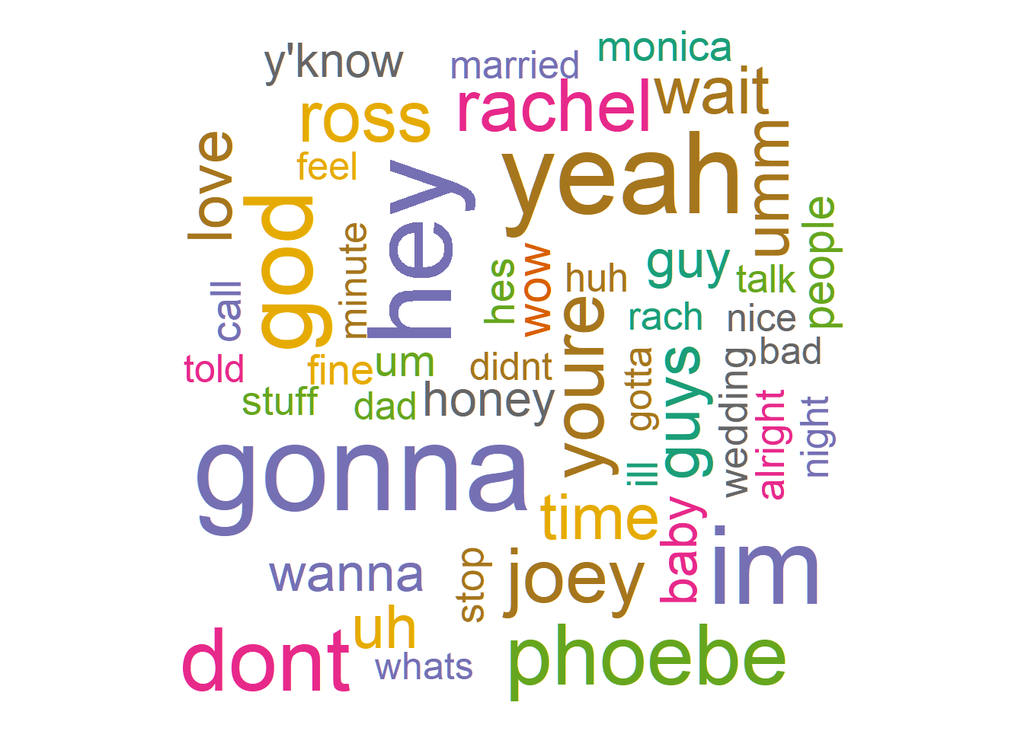

## Linguistic Analysis

The average number of words in a dialogue in friends is **10.63**

However, the average of all the words in each sentence of a dialogue spoken by all the characters is **6.43**

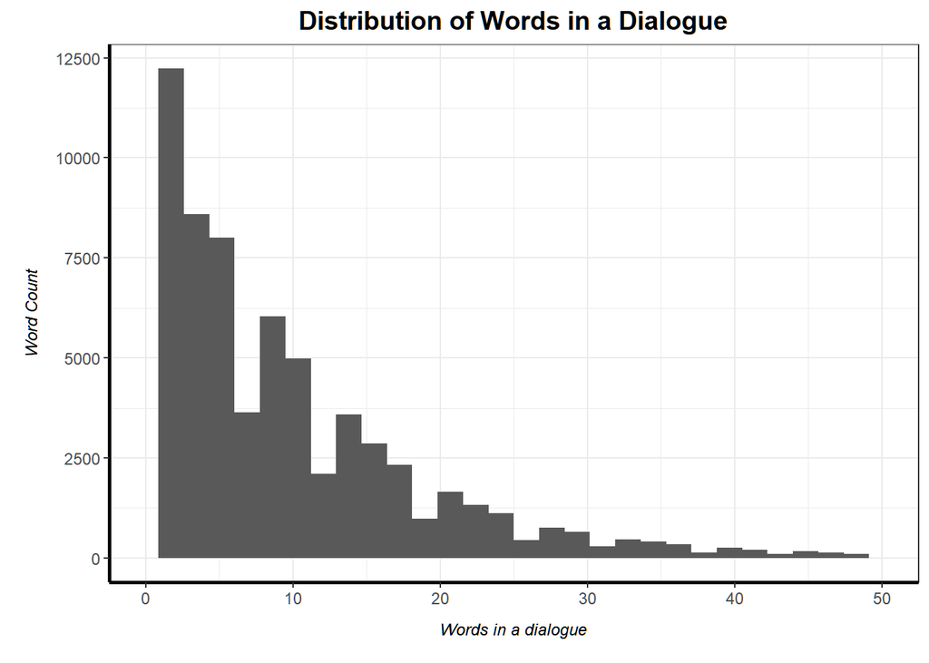

### **Count of words spoken by each character per season**

|  | Character | Season.1 | Season.2 | Season.3 | Season.4 | Season.5 | Season.6 | Season.7 | Season.8 | Season.9 | Season.10 |
| --- | --- | --- | --- | --- | --- | --- | --- | --- | --- | --- | --- |
| 1 | Monica | 8234 | 8534 | 8651 | 7836 | 9001 | 9058 | 9961 | 9141 | 9460 | 7590 |
| 2 | Rachel | 9166 | 9399 | 9120 | 9645 | 10641 | 11071 | 12187 | 11887 | 10661 | 8773 |
| 3 | Phoebe | 6771 | 9488 | 9571 | 8606 | 9236 | 8738 | 8538 | 8036 | 10209 | 8060 |
| 4 | Ross | 10427 | 9802 | 10965 | 8922 | 9734 | 10370 | 9338 | 10509 | 11492 | 9267 |
| 5 | Chandler | 9058 | 9353 | 9173 | 9641 | 8957 | 11200 | 9159 | 6629 | 11813 | 7233 |
| 6 | Joey | 6582 | 8075 | 8866 | 8781 | 10354 | 11258 | 10389 | 10978 | 10144 | 7839 |

### **Overview of verbosity per character**

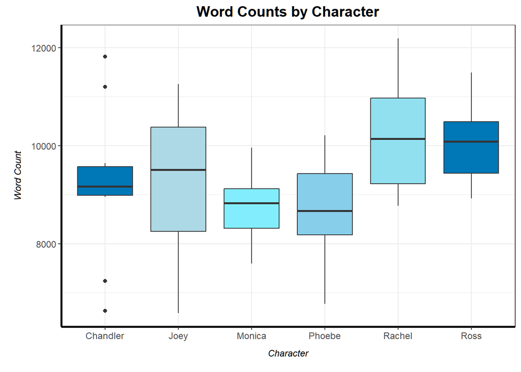

### **Analysis of the words spoken by the main characters in friends**

|  | Speaker | Total Sentences | AverageWords | MinWords | MaxWords | SD_Words |
| --- | --- | --- | --- | --- | --- | --- |
| 1 | Chandler | 6387 | 13.32 | 3 | 123 | 10.84 |
| 2 | Joey | 6159 | 14.01 | 3 | 168 | 11.94 |
| 3 | Monica | 6210 | 12.90 | 3 | 225 | 10.40 |
| 4 | Phoebe | 5674 | 14.18 | 3 | 225 | 12.38 |
| 5 | Rachel | 6634 | 14.31 | 3 | 205 | 12.42 |
| 6 | Ross | 6598 | 14.13 | 2 | 188 | 11.76 |

### **Most common words used in sentences with more than 3 words**

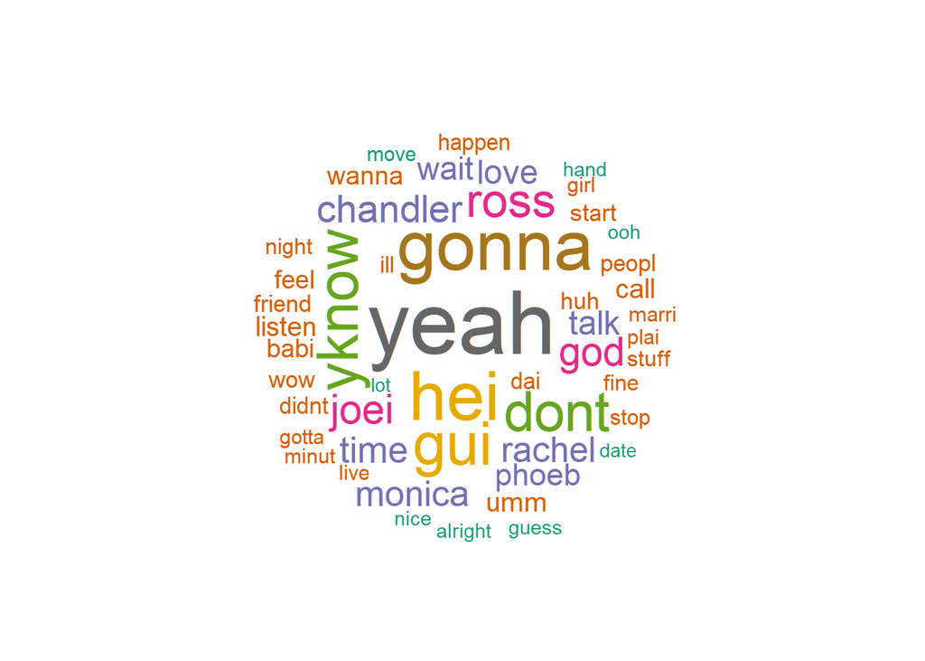

### **Most used verbs by the main characters**

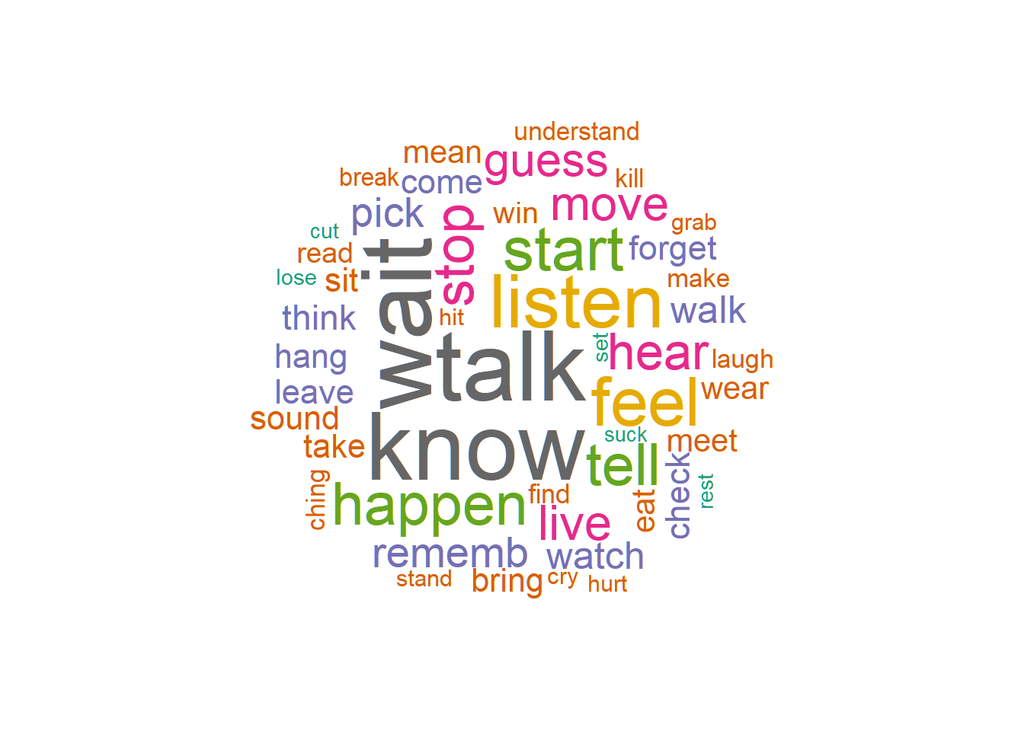

### **Most used adjectives by the main characters**

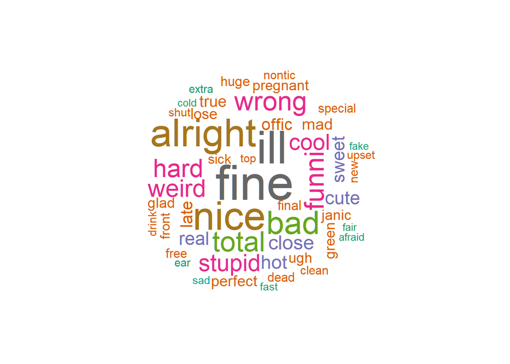

### **Most Verbs used by men**

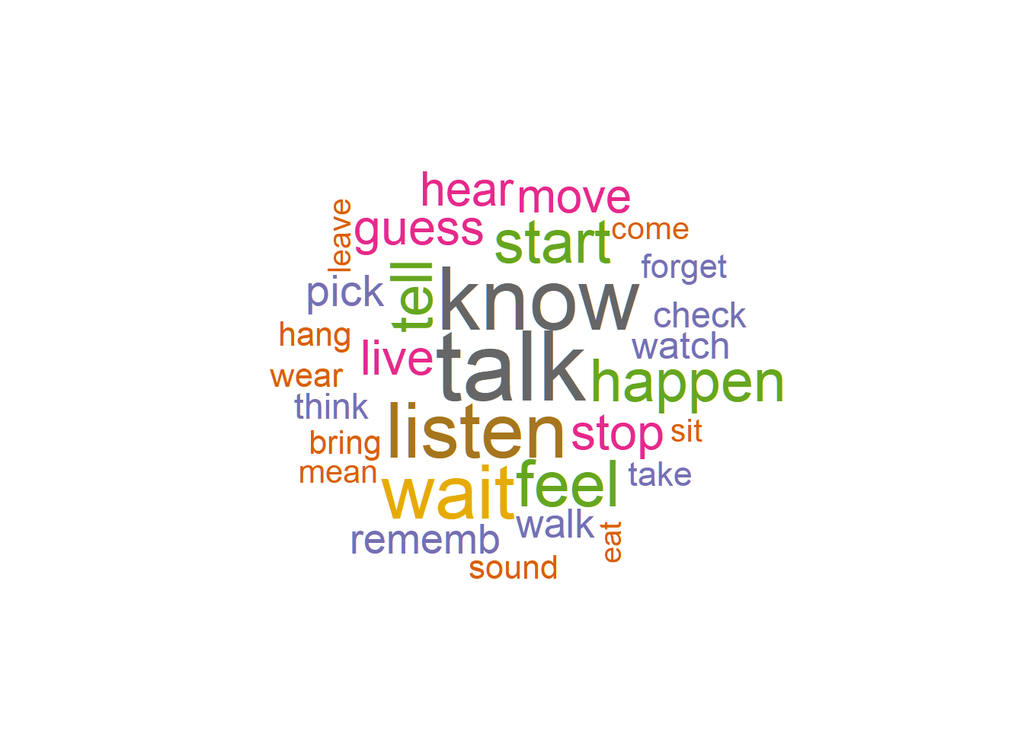

### **Most Verbs used by Women**

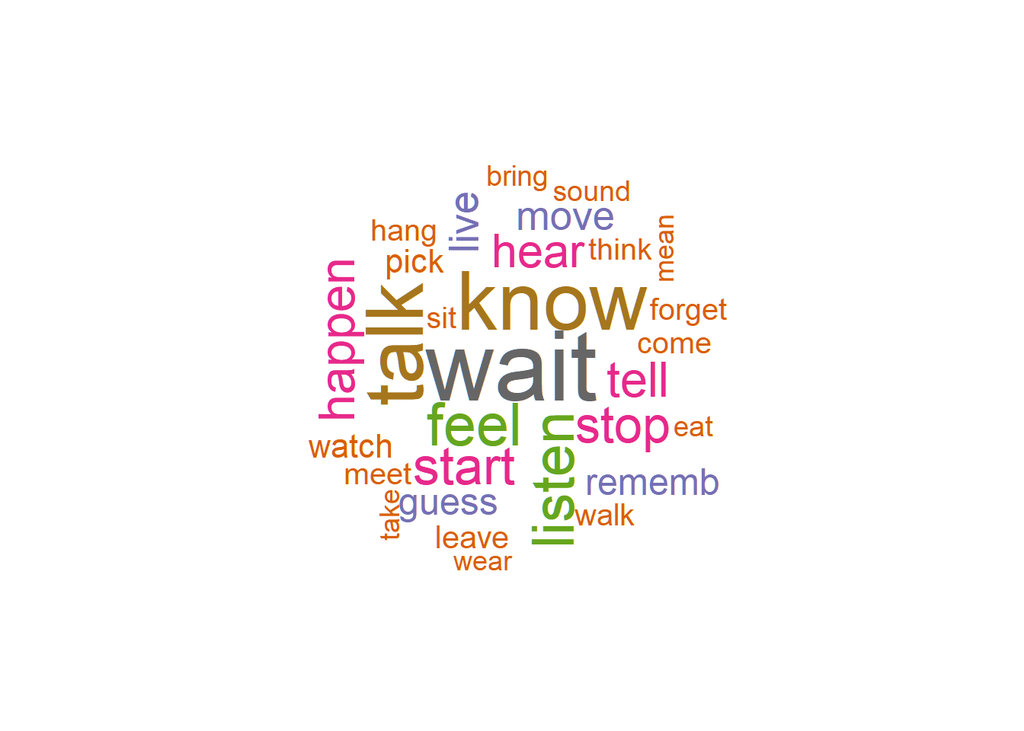

### **Most Nouns used by Women**

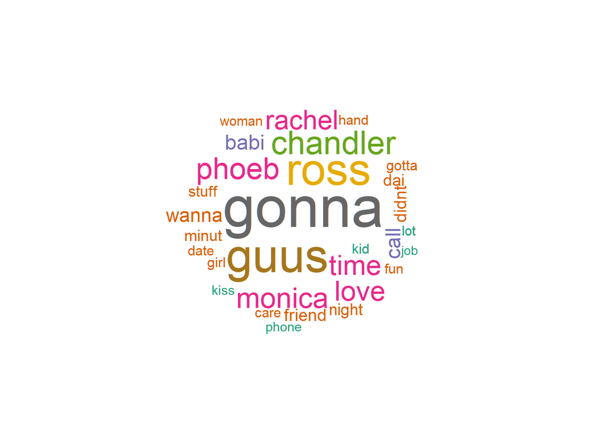

### **Most Nouns used by Men**

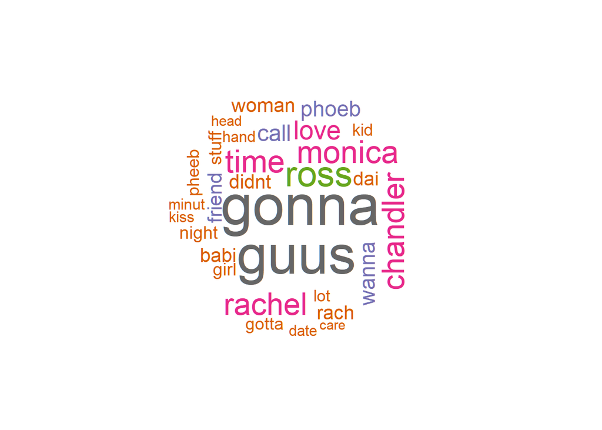

### **Most Adjectives used by Women**

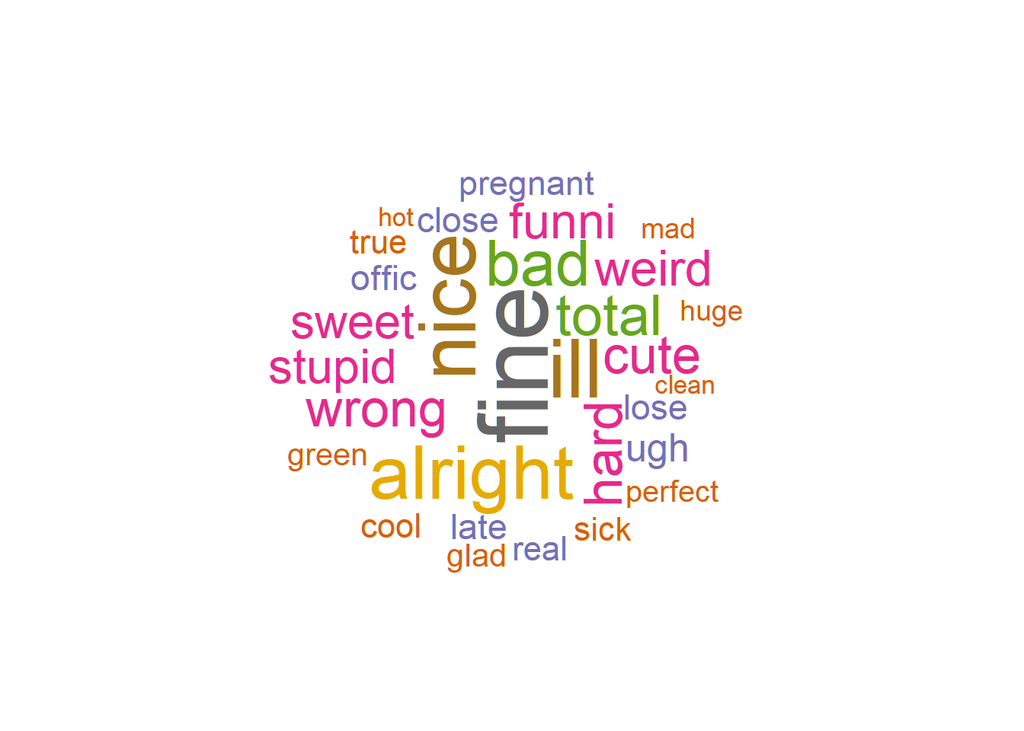

### **Most Adjectives used by Men**

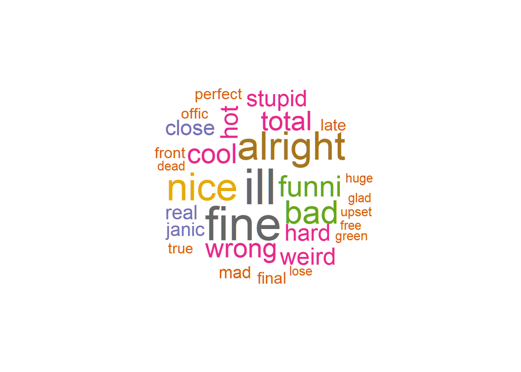

### **Sentence Analysis of the 6 Main Characters of Friends TV Series**

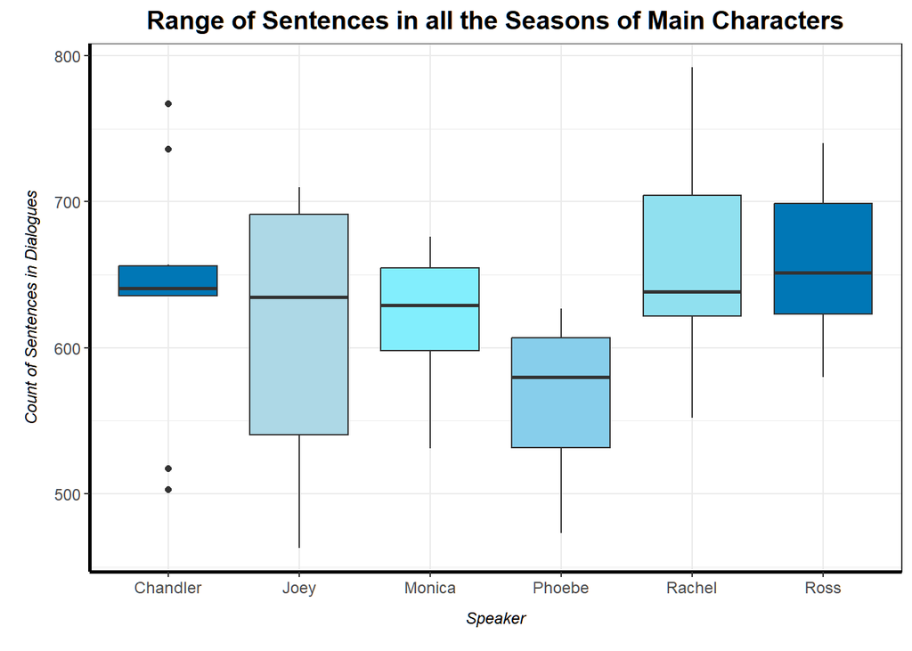

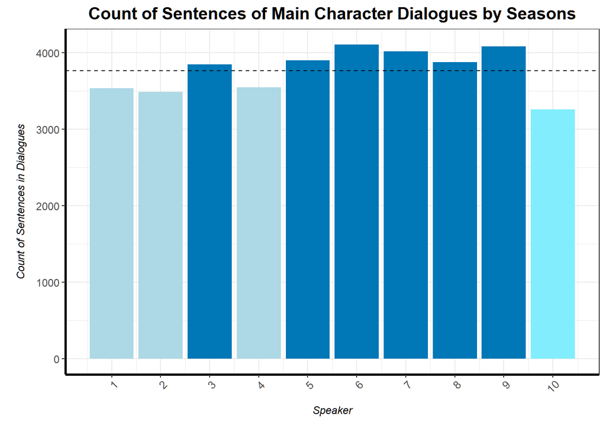